# BTTH7

22521706_Nguyễn Thị Thuý Vy

BÀI THỰC HÀNH 7

```python
from google.colab import drive
import pandas as pd
import numpy as np
```

```python
drive.mount('/content/drive')
```

1. Đọc tệp CSV, phân tích cột 'Date' dưới dạng datetime, và thiết lập cột trên làm chỉ mục.

```python
df = pd.read_csv('/content/drive/MyDrive/Colab Notebooks/BT7.future-gc00-daily-prices.csv')
```

```python
df['Date'] = pd.to_datetime(df['Date'], errors='coerce')
```

```python
df.set_index('Date', inplace=True)
```

2. Sắp xếp DataFrame theo chỉ mục 'Date' theo thứ tự tăng dần.

```python
df.sort_index(ascending=True, inplace=True)
```

3. Làm sạch cột "Close": Loại bỏ dấu phẩy khỏi dữ liệu trong cột "Close", chuyển đổi giá trị thành kiểu số học, thay thế các giá trị vô hạn (nếu có) thành NaN và loại bỏ các dòng có giá trị NaN trong cột "Close".

```python
# Xóa dấu phẩy nếu có
df['Close'] = df['Close'].replace({',': ''}, regex=True)

# Chuyển thành số thực
df['Close'] = pd.to_numeric(df['Close'], errors='coerce')

# Thay thế vô cực bằng NaN
df['Close'] = df['Close'].replace([np.inf, -np.inf], np.nan)

# Xóa dòng chứa NaN ở cột Close
df.dropna(subset=['Close'], inplace=True)
```

```python
print(df.head())
```

```
              Open    High     Low  Close
Date
2009-04-24  905.50  915.40  904.20  914.1
2009-04-27  915.00  919.70  905.80  908.2
2009-04-28  907.20  907.70  884.60  893.6
2009-04-29  894.00  904.00  888.30  900.5
2009-04-30  898.60  900.80  880.10  891.2
```

4. Vẽ đồ thị giá "Close" theo thời gian: Đoạn mã này tạo một biểu đồ, vẽ giá đóng cửa của cổ phiếu theo chỉ mục thời gian, thêm tiêu đề, nhãn cho trục x và y, và hiển thị đồ thị.

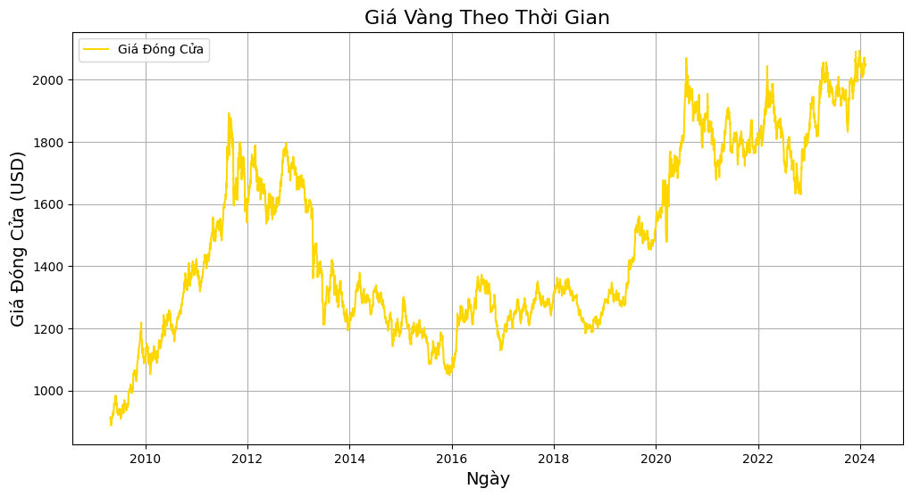

```python
import matplotlib.pyplot as plt

# Vẽ đồ thị giá "Close" theo thời gian
plt.figure(figsize=(12, 6))
plt.plot(df.index, df['Close'], label='Giá Đóng Cửa', color='gold')

# Thêm tiêu đề và nhãn trục
plt.title('Giá Vàng Theo Thời Gian', fontsize=16)
plt.xlabel('Ngày', fontsize=14)
plt.ylabel('Giá Đóng Cửa (USD)', fontsize=14)

# Hiển thị lưới
plt.grid(True)

# Hiển thị chú thích
plt.legend()

# Hiển thị đồ thị
plt.show()
```

5. Kiểm tra tính dừng (stationarity) và thực hiện phép sai phân (differencing) nếu cần Hướng dẫn: sử dụng kiểm định Augmented Dickey-Fuller (adfuller)

```python
!pip install statsmodels
```

```python
from statsmodels.tsa.stattools import adfuller

# Thực hiện kiểm định ADF
result = adfuller(df['Close'])

# In kết quả kiểm định
print('ADF Statistic:', result[0])
print('p-value:', result[1])
print('Số lượng độ trễ sử dụng:', result[2])
print('Số lượng quan sát:', result[3])
print('Các giá trị tới hạn:')
for key, value in result[4].items():
    print(f'   {key}: {value}')
```

```
ADF Statistic: -1.4366521533746122
p-value: 0.5645840212905483
Số lượng độ trễ sử dụng: 11
Số lượng quan sát: 3712
Các giá trị tới hạn:
   1%: -3.4321128846593014
   5%: -2.862318944916725
   10%: -2.5671846435169487
```

=> Chuỗi gốc là không dừng (Non-Stationary) vì p-value > 0.05.

```python
# Sai phân bậc 1
df['Close_diff'] = df['Close'].diff()

# Bỏ giá trị NaN sau sai phân
df.dropna(subset=['Close_diff'], inplace=True)

# Kiểm tra lại tính dừng sau sai phân
result_diff = adfuller(df['Close_diff'])

print('ADF Statistic after differencing:', result_diff[0])
print('p-value after differencing:', result_diff[1])
```

```
ADF Statistic after differencing: -19.130833249489253
p-value after differencing: 0.0
```

=> Chuỗi đã chênh lệch là dừng (Stationary) vì p-value < 0.05.

6. Vẽ đồ thị giá "Close" đã sai phân: Đoạn mã này tạo một biểu đồ, vẽ giá "Close" đã sai phân theo chỉ mục thời gian, thêm tiêu đề, nhãn cho trục x và y, và hiển thị đồ thị với màu cam (orange).

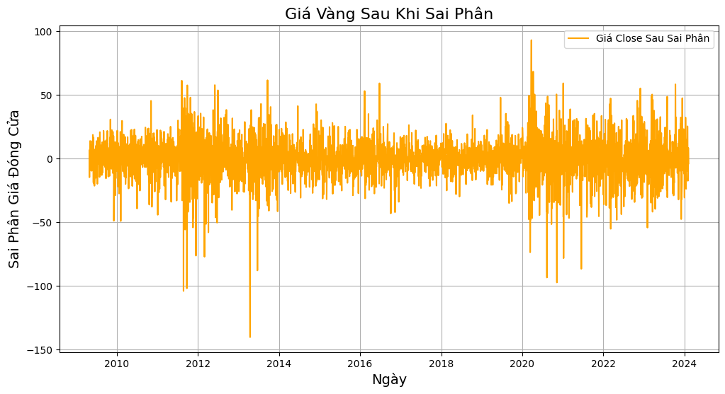

```python
import matplotlib.pyplot as plt

# Vẽ đồ thị giá "Close" sau khi sai phân
plt.figure(figsize=(12, 6))
plt.plot(df.index, df['Close_diff'], label='Giá Close Sau Sai Phân', color='orange')

# Thêm tiêu đề và nhãn trục
plt.title('Giá Vàng Sau Khi Sai Phân', fontsize=16)
plt.xlabel('Ngày', fontsize=14)
plt.ylabel('Sai Phân Giá Đóng Cửa', fontsize=14)

# Hiển thị lưới
plt.grid(True)

# Hiển thị chú thích
plt.legend()

# Hiển thị đồ thị
plt.show()
```

7. Tìm các tham số ARIMA Sử dụng các công cụ như ACF (Autocorrelation Function) và PACF (Partial Autocorrelation Function) với lags = 40 để xác định giá trị của p, d và q. Số lượng độ trễ (lags) mà ACF cắt đứt là q, và nơi PACF cắt đứt là p. Cần chọn giá trị thích hợp cho d bằng cách tạo ra một tình huống mà sau khi thực hiện phép sai phân (differencing), dữ liệu giống như nhiễu trắng (white noise).

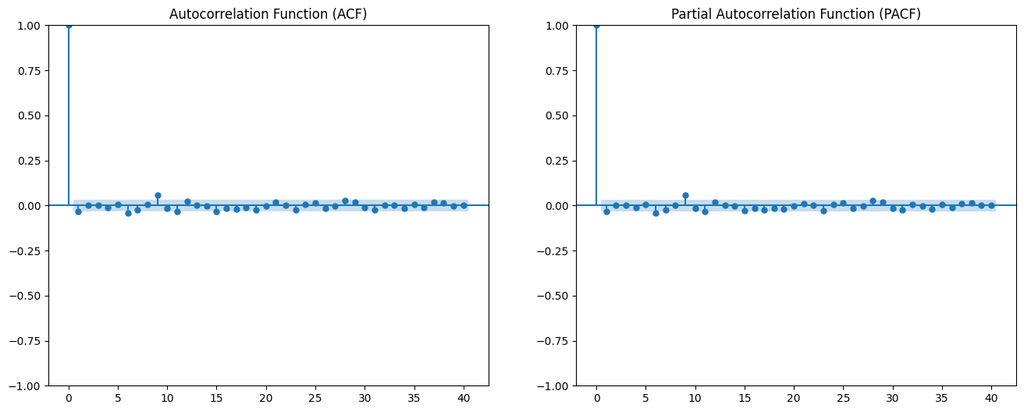

```python
from statsmodels.graphics.tsaplots import plot_acf, plot_pacf
import matplotlib.pyplot as plt

# Vẽ ACF và PACF cho dữ liệu đã sai phân
fig, axes = plt.subplots(1, 2, figsize=(16, 6))

# ACF plot
plot_acf(df['Close_diff'], lags=40, ax=axes[0])
axes[0].set_title('Autocorrelation Function (ACF)')

# PACF plot
plot_pacf(df['Close_diff'], lags=40, ax=axes[1], method='ywm')
axes[1].set_title('Partial Autocorrelation Function (PACF)')

plt.show()
```

8. Chia tập dữ liệu thành Train và Test theo tỷ lệ 8-2 (80% chuỗi ở phần đầu là Train, 20% chuỗi ở phần cuối là Test). Và tiến hành huấn luyện mô hình ARIMA với p=1, d=1, q=1

```python
# Số lượng mẫu
n = len(df)

# Chia 80% đầu làm train, 20% cuối làm test
train_size = int(n * 0.8)

train = df['Close'][:train_size]
test = df['Close'][train_size:]
```

```python
from statsmodels.tsa.arima.model import ARIMA

# Xây dựng mô hình ARIMA(1,1,1) trên tập train
model = ARIMA(train, order=(1, 1, 1))
model_fit = model.fit()

# In ra summary của mô hình
print(model_fit.summary())
```

```
                               SARIMAX Results
==============================================================================
Dep. Variable:                  Close   No. Observations:                 2978
Model:                 ARIMA(1, 1, 1)   Log Likelihood              -12294.762
Date:                Wed, 09 Apr 2025   AIC                          24595.524
Time:                        03:48:09   BIC                          24613.520
Sample:                             0   HQIC                         24602.000
                               - 2978
Covariance Type:                  opg
==============================================================================
                 coef    std err          z      P>|z|      [0.025      0.975]
------------------------------------------------------------------------------
ar.L1         -0.4247      0.260     -1.636      0.102      -0.934       0.084
ma.L1          0.3895      0.264      1.476      0.140      -0.128       0.907
sigma2       226.3221      2.793     81.032      0.000     220.848     231.796
===================================================================================
Ljung-Box (L1) (Q):                   0.02   Jarque-Bera (JB):              9543.32
Prob(Q):                              0.89   Prob(JB):                         0.00
Heteroskedasticity (H):               0.82   Skew:                            -0.80
Prob(H) (two-sided):                  0.00   Kurtosis:                        11.62
===================================================================================

Warnings:
[1] Covariance matrix calculated using the outer product of gradients (complex-step).
```

9. Tiến hành dự báo trên Test và vẽ biểu đồ hiển thị kết quả

```python
# Dự báo số bước bằng đúng độ dài test
forecast = model_fit.forecast(steps=len(test))

# In ra 5 giá trị đầu tiên
print(forecast.head())
```

```
2978    1806.418141
2979    1806.198073
2980    1806.291541
2981    1806.251843
2982    1806.268704
Name: predicted_mean, dtype: float64
```

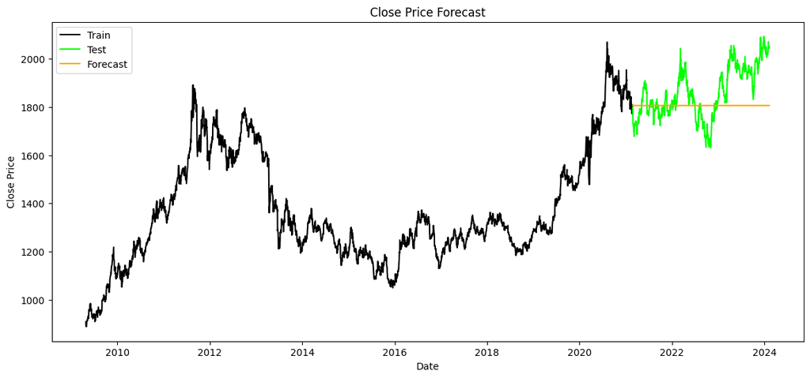

```python
import matplotlib.pyplot as plt

plt.figure(figsize=(14, 6))

# Vẽ train
plt.plot(train.index, train, label='Train', color='black')

# Vẽ test
plt.plot(test.index, test, label='Test', color='lime')

# Vẽ forecast
plt.plot(test.index, forecast, label='Forecast', color='orange')

# Tiêu đề và nhãn
plt.title('Close Price Forecast')
plt.xlabel('Date')
plt.ylabel('Close Price')

# Hiển thị chú thích (legend)
plt.legend()

# Hiển thị biểu đồ
plt.show()
```

10. Đánh giá các chỉ số mô hình bằng AIC, BIC, và RMSE

```python
# In AIC và BIC
print('AIC:', model_fit.aic)
print('BIC:', model_fit.bic)
```

```
AIC: 24595.52433576541
BIC: 24613.52034984846
```

```python
from sklearn.metrics import mean_squared_error
import numpy as np

# Tính RMSE
rmse = np.sqrt(mean_squared_error(test, forecast))
print('RMSE:', rmse)
```

```
RMSE: 118.53325436389366
```